# Mean Population Elevation in the Continental USA

Daniel Moul

2020-10-23

The continental United States has vast flat plains and long mountain ranges. But what do people experience? They don’t live at the the extreme highest and lowest elevations. One way to answer this question is find the average elevation of the population of the USA. We can approximate the answer by doing the following:

1. Calculate the mean elevation of each county based on the elevations of a set of populated places in each county
2. Get the population of each county
3. Calculate a weighted mean elevation for the country based on the above

## 1. Calculate mean elevation of each county

We can approximate the mean elevation of each county using the ‘populated places’ data set from the USGS [Populated Places](https://geonames.usgs.gov/docs/stategaz/POP_PLACES.zip) topical gazetteer from GNIS. Most counties have more than 10 populated places, and we can average them to get an approximation for the mean elevation of the county.

Example data from USGS ‘Populated Places’ data set with calculated mean elevation per county

| state_alpha | state_numeric | county_name | county_numeric | n_poplulated_places | mean_elev_in_m | mean_elev_in_ft |
| --- | --- | --- | --- | --- | --- | --- |
| IA | 19 | Carroll | 027 | 21 | 391 | 1284 |
| IN | 18 | Fayette | 041 | 16 | 285 | 935 |
| KY | 21 | Kenton | 117 | 63 | 214 | 701 |
| NE | 31 | Dawes | 045 | 14 | 1114 | 3654 |
| NE | 31 | Deuel | 049 | 5 | 1091 | 3579 |
| TX | 48 | Ellis | 139 | 55 | 163 | 533 |
| TX | 48 | Hill | 217 | 43 | 194 | 638 |
| TX | 48 | Hunt | 231 | 52 | 163 | 535 |
| TX | 48 | Navarro | 349 | 51 | 130 | 427 |
| VA | 51 | Buckingham | 029 | 52 | 151 | 495 |

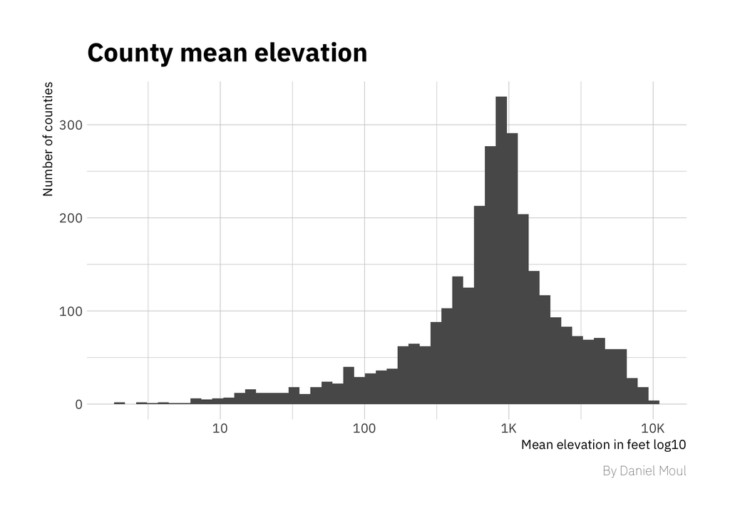

## 2. Get population by county

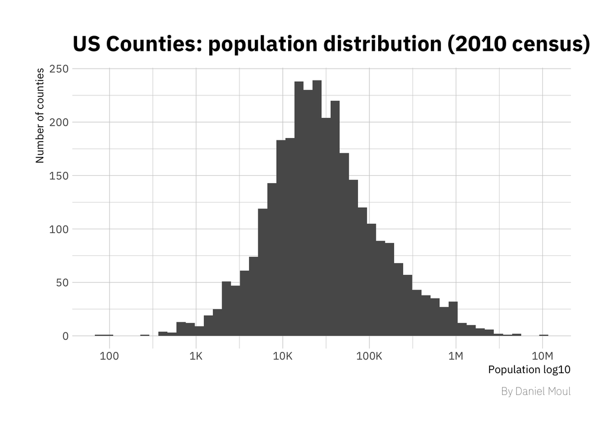

## 3. The answer

The average elevation of the population of the USA is 856 ft, which is a weighted mean based on county population. Compare that to the simple average of county elevation: 1302 ft. It seems reasonable to me that weighted mean is lower elevation than the simple mean, since there are more people near the coasts in higher-density counties than in the middle of the country and in mountainous areas.

Note that counties in Alaska and Hawaii were included when calculating the mean, however they are not included in the plot below.

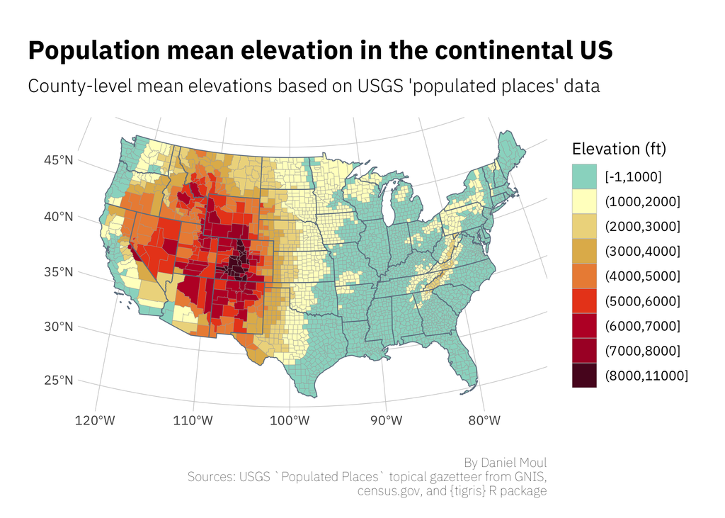

Most people live in the green counties (below 1000 ft elevation).

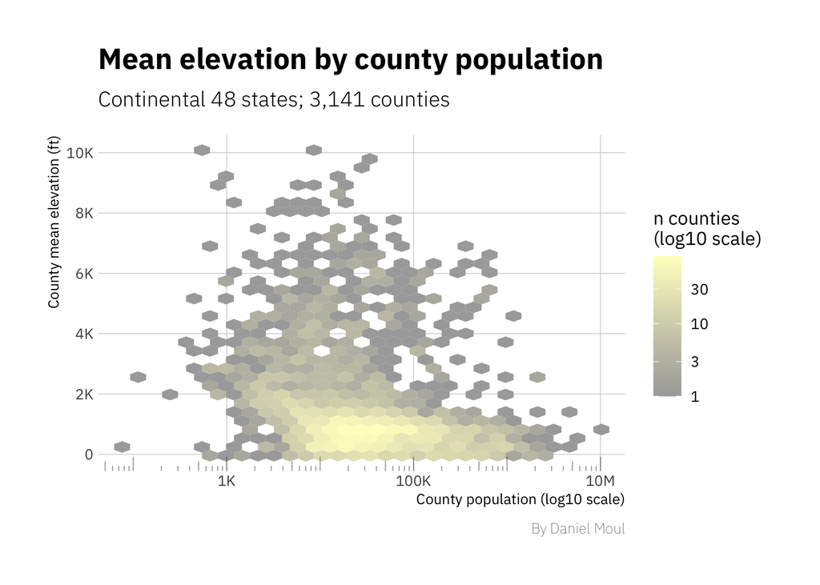

Three states (AZ, CA, CO) have a range of more than a mile in elevation between the lowest and highest mean county elevations.

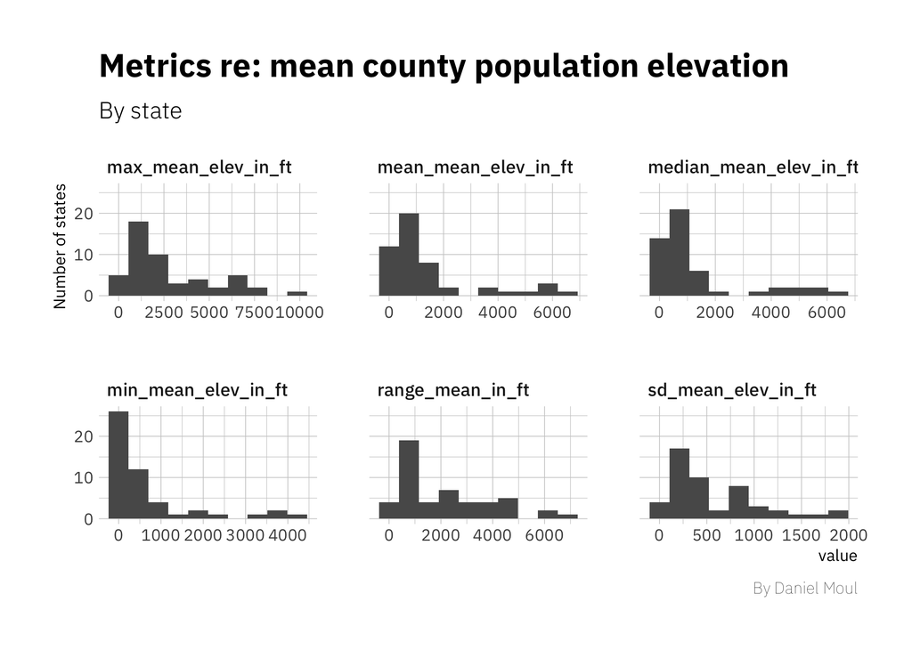

## 4. Notes

Can we rely on the population mean elevation calculated based on “populated places?” Yes, because (1) 94% of the counties have more than 10 populated places ; and (2) those with less are mostly sparsely populated ranching and farming areas in a band from Texas to North Dakota where it’s relatively flat.

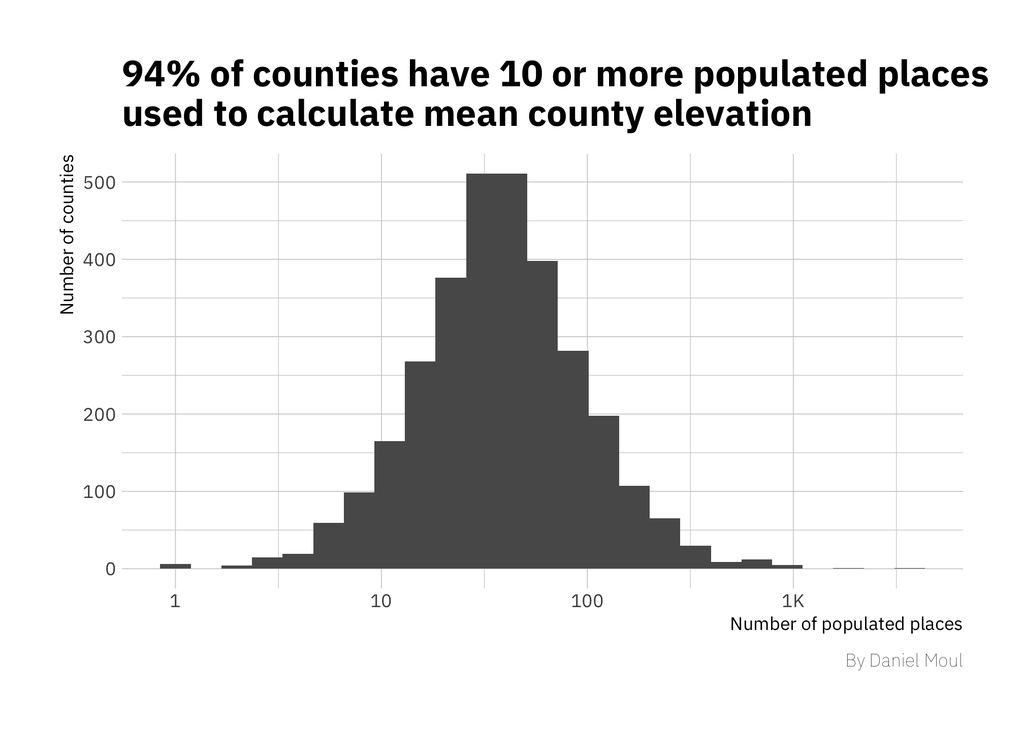

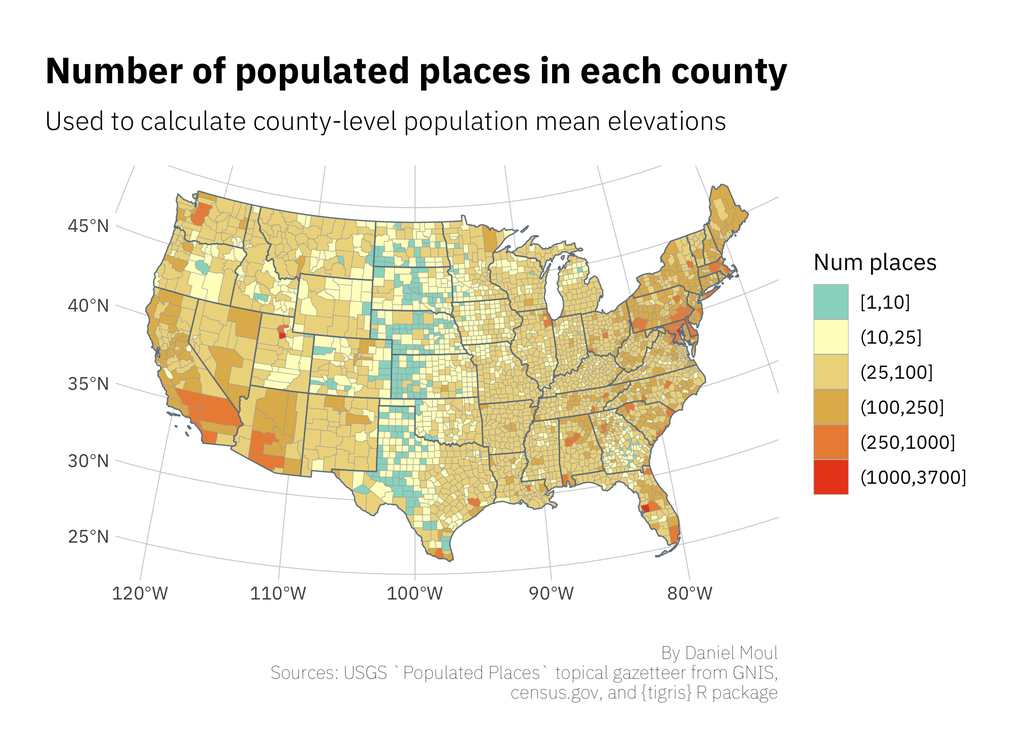

By Daniel Moul (heydanielmoul via gmail)

This work is licensed under a [Creative Commons Attribution 4.0 International License](http://creativecommons.org/licenses/by/4.0/)